# EPhyNE Guide: Fitting your data to PhyNE

Sean McHugh

2022-07-01

## EPhyNE intro

Hello and thank you for checking out EPhyNE (fka PhyNE). This guide will show how to fit a set of spatial Presence and Absence/PsuedoAbsences with corresponding environmental data (ex WorldClim or envirem) to EPhyNE and recover estimates of unimodal symmatric response curves with 3 parameters: optimum, breadth, and (optionally) tolerance. For each environmental predictor for each species and estimates of the the evolutionary model parameters. Each curve evolves under a separate multivariate brownian motion (mvBM) where the optimum and breadth (and tolerance optionally) evolve given a an ancestral root mean and variance covariance matrix describing the rates of evolution and covariance between each response curve parameter

NOTE: all environmental predictor response curves are currently set as uncorrelated, if trying to estimate phylogenetic niche in temperature and precipitation, the impact of precipitation and temperature on occurrence would be unlinked (no correlation estimated in species specific ENMs) and also the covariance in response curve parameters are not modeled across predicotrs, only between (such that there is a correlation between precipitation optimum and breadth but not precipitation optimum and temperature optimum) Covariation in these predictors is very interesting and important next step in improving this models and other similar ones.

## Getting started: Data Format

This on the back end get formatted as a list of lists were each list includes the species name, the vector of P/A, and vectors for the corresponding environmental predictor values.

```r
#devtools::install()
library(EPhyNE)
library(treeplyr)
require(readr)
require(tibble)
require(MCMCpack)
require(devtools)
require(coda)
require(devtools)
require(coda)
require(ape)
require(truncdist)
require(geiger)
require(phytools)
require(tidyr)
require(ratematrix)
require(mvMORPH)
require(dplyr)
require(mvtnorm)
require(MultiRNG)
require(Rphylopars)
require(Rcpp)
require(doParallel)
require(corpcor)
require(Matrix)
require(treeplyr)
require(bayou)
require(crayon)
require(shape)
require(scales)
require(phytools)
require(robustbase)
data(ENA_Pleth_PA)

#loading in the data had an issue needed to convert rows back to numeric (except species of course)
ENA_Pleth_PA[,c(1:2,4:6)]<-do.call(cbind,lapply(X = ENA_Pleth_PA[,c(1:2,4:6)], FUN=as.numeric))

#load tree
data(ENA_Pleth_Tree)

tree<-ENA_Pleth_Tree
```

We can then extract a vector of unique genus names in the dataset using some janky code, we will just use this to plot the data in environmental and geographic space.

```r
# number of rows
nrow(ENA_Pleth_PA)
```

```
#> [1] 120308
```

```r
#number of unique species
species=as.list(unique(ENA_Pleth_PA$species))

names(species)<-species

genera<-unique(unlist(lapply(tree$tip.label, function(x) scan(text=x, sep="_", what="", quiet=TRUE)[1])))
```

## Checking the Data

We can plot our data both spatially and over climate space chose a species and plot (we are not going to try plotting all 82 at once)

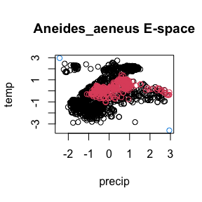

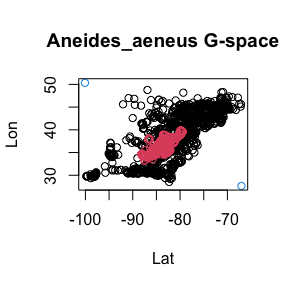

```r
#class(ENA_Pleth_PA)
sp<-species$Aneides_aeneus



#plot occurrence data for species in Envrionmental space ("E-space")
plot(c(min(ENA_Pleth_PA$X1),max(ENA_Pleth_PA$X1)),
     c(max(ENA_Pleth_PA$X2),min(ENA_Pleth_PA$X2)), xlab="precip",ylab="temp",main=paste(sp, "E-space"), col=4)

points(ENA_Pleth_PA[ ( ENA_Pleth_PA$species==sp & ENA_Pleth_PA$y==0 ) ,5:6], col=1)

points(ENA_Pleth_PA[ ( ENA_Pleth_PA$species==sp & ENA_Pleth_PA$y==1 ) ,5:6], col=2)


#plot occurrence data for species in Geographic space space ("G-space")
plot(c(min(ENA_Pleth_PA$Lat),max(ENA_Pleth_PA$Lat)),
     c(max(ENA_Pleth_PA$Lon),min(ENA_Pleth_PA$Lon)), xlab="Lat",ylab="Lon",main=paste(sp, "G-space"), col=4)


points(ENA_Pleth_PA[ ( ENA_Pleth_PA$species==sp & ENA_Pleth_PA$y==0 ) ,1:2], col=1)

points(ENA_Pleth_PA[ ( ENA_Pleth_PA$species==sp & ENA_Pleth_PA$y==1 ) ,1:2], col=2)
```

So we have a dataset, now it is time to put it into a form EPhyNE can read, and then start setting up the details for our MCMC run. EPhyNE reads a list of lists of your PA dtaa and occurrences over each species such that for one species (the way ENA_Pleth_PA is converted to data_final makes column order essential) (NOTE: Lat and Lon are removed at this stage) data_final[[1]] $speciesname $ vector of y (1’s and 0’s for presences and absences) $ vector X1 $ vector X2 $ vector Xetx

```r
#
data_final<- lapply(split(ENA_Pleth_PA[3:6],ENA_Pleth_PA$species), as.list)
#replace vector of species names with a single name
for (sp in 1:length(data_final)) {

  data_final[[sp]]$species= data_final[[sp]]$species[[1]]

}



# match data_final species order to tree tip order
data_final=data_final[order(match(unlist(lapply(data_final, function(sp) sp$species)), tree$tip.label))]
```

## Setting up the MCMC:Choose Your Priors

Now that we have our dataset we can start the exciting task of setting our priors, we will inform our parameters with informative/weakly informative priors (entirely uninformative uniform priors can lead to some weird behavior especially for niche breadth and mvBM pars)

For our dataset (and any other using pseudo absence data generated from background points or some other unbalanced sampling that doesnt reflect true prevalence) I would recommend only estimating optimum and breadth from the mvBM model, and leave tolerance to only be estimated from the data

```r
unif=F
norm=T
preds=2
pred=2

unipred=F
test_BM=F

#specifiy predictor that needs to be fixed, or set to FALSE, and set center to what you want it fixed to, if for sal precip, er the better likely
center_fixed=F

v=c(.05, .05)
k=lapply(1:length(v), function(x) log(v[[x]]/(1-v[[x]])))


#
#identify the range you expect breadth to be in, if
max_bd<-1.5

min_bd<-.1

bd <-((log(max_bd)-log(min_bd))/4)^2

#get number of environmental predictors

pred=length(data_final$Stereochilus_marginatus[3:length(data_final[[1]])])

#set means for prior distributions for mvBM rates
par.sd.lnorm.meanlog<-list(c(log(.2),  log(bd)) #pred 1 (center, width)
                           ,c(log(.2), log(bd)) #pred 2
)


#set sd for prior distributions for mvBM rates

par.sd.lnorm.sdlog<-list(c(.1, .1) #pred 1
                         ,c(.1, .1) #pred 2
)


#compile sd and means into single objects

par.sd.lnorm <-lapply(1:pred, function(x) cbind(par.sd.lnorm.meanlog[[x]], par.sd.lnorm.sdlog[[x]]))

par.sd.lnorm <-lapply(1:pred, function(x) cbind(par.sd.lnorm.meanlog[[x]], par.sd.lnorm.sdlog[[x]]))



#set pars for prior distributions of mvBM root means

par.mu.norm<-list( matrix(c(  0,  .5, #center(norm)
                       log(0.3), .2), #width (lnorm)
                        nrow = 2, ncol = 2, byrow = TRUE), #pred 1 root prior (center mean, center sd, width mean, width sd)
                  matrix(c(0, .5,
                    log(0.3), .2),
                    nrow = 2, ncol = 2, byrow = TRUE) #pred 2 root prior (center mean, center sd, width mean, width sd)
)
```

Since tolerance are not part of the mvBM in the analysis and only estimated from the glm we will put priors on each tip. with the mean being a max likelihood estimate for tolerance Note what we are doing here is a little janky/circular as we are using max likelihood GLM(NOTE) estimates as the means, this is just a weak prior to place it somewhere between .05 and .99. You could use a flat prior but it will result in EPhyNE taking much longer to mix.

we do not believe this actually reflect prevalence, but instead error in sampling of the occurrences (broad scale gbif data) and generated absence data (using target group absences filtered to an equal number within the species IUCN expert range map and double the number of presences outside the expert range), see the pre print for details

(NOTE) Generalized linear model: just the function we are fitting for each individual species response curve in PhyNE (logit(y) = B0 + B1 * X1 + B2 * X2)

```r
#warning the GLM from this simple one predictor model is going to be messy (lot of "Warning: glm.fit: fitted probabilities numerically 0 or 1 occurred") we dont expect the estimate to be accurate we just are trying to get a rough guess of where tolerance may be, and starting values for our individual species response curves

GLM_only_ml<-suppressWarnings(MLglmStartpars(species_data = data_final,tree = tree, height = NULL))


heights_glm<- lapply(GLM_only_ml$start_pars_bt, function(pred) pred[,3])
```

Now we have all the pieces needed to construct our Prior functions, these are what will be passed through EPhyNE’s MCMC to calculate the prior likelihood our parameters

```r
Prior_scale <-lapply(1:pred, function(x) makePrior_ENE(r = 2, p=1, #p is the number of regimes, currently EPhyNE is only capable of modeling one, but stay tuned!
                                                       den.mu = "norm",
                                                       heights_by_sp = heights_glm[[x]],
                                                       par.mu = par.mu.norm[[x]],
                                                       den.sd = "lnorm" ,
                                                       par.sd = par.sd.lnorm[[x]],
                                                       plot=F))
```

## Setting up the MCMC:Choose Your Starting Values

```r
# chose one of two options:

heights_glm[[2]][[5]]=.9

# Simulate mvBM and starting individual species responses
repeat{

  startPars_scaled <- priorSim_pars(Prior_scale, tree, dist="norm",hard_coded_heights = heights_glm)

  #break when no tip has a -inf likelihood

  if(length(findBadStart(res=startPars_scaled$sim_dat$sim_dat_bt, pa_data=data_final, plot=F))==0){break}


}


findBadStart(res=startPars_scaled$sim_dat$sim_dat_bt, pa_data=data_final, plot=F)
```

```
#> integer(0)
```

```r
# Simulate mvBM and use GLM estimates as starting individual species responses

#startPars_scaled$sim_dat$sim_dat_bt<- GLM_only_ml$start_pars_bt
#
#findBadStart(res=startPars_scaled$sim_dat$sim_dat_bt, pa_data=data_final, plot=F)
#
#
#start_good<-findStart(res=startPars_scaled$sim_dat$sim_dat_bt, pa_data=data_final, tree, plot=F)
```

## Setting up the MCMC:Choose Your Tuning Parameters

Next you need to set your tuning parameters, how often do we want to be making proposals on any specific parameter, we set these through trial and error on our scaled predictors, each tip response par and mvBM par has its own tuning par in this setup, each response curve proposal type (center_lide, center_mult, width_slide, etc) has its own tuning par

```r
    center_slide=.18
    center_mult=.12
    width_slide=.15
    width_mult=.2
    height_slide=.5
    height_mult=.3

    tuning<-  list(
      niche_prop= lapply(1:pred, function(pred) list(slide=tibble(center=sample(center_slide, length(tree$tip.label), replace=T),
                                                                  width= sample(width_slide, length(tree$tip.label), replace=T),
                                                                  height= sample(height_slide, length(tree$tip.label), replace=T) ),
                                                      multi=tibble(center=sample(center_mult , length(tree$tip.label), replace=T),
                                                                   width= sample(width_mult , length(tree$tip.label), replace=T),
                                                                   height= sample(height_mult, length(tree$tip.label), replace=T)  )
      )),

      w_mu =  lapply(1:pred, function(pred) list(slide=c(.6,.6),
                                                  multi=c(.6,.6)))
      ,

      w_sd =  lapply(1:pred, function(pred)  list(slide=c(.15,.12),
                                                   multi=c(.15,.12))
      ),

      v_cor       = lapply(1:pred, function(pred) 100)
    )
```

##Run Your MCMC (Fingers Crossed)

```r
#
sets_full<-suppressWarnings(separate.data(data_final,ratio = .5))


  sparse_sp=F
  iterations=10000
  trim_freq= 10
  burnin=0
  chain_end=(iterations-(burnin))/trim_freq
  plot=F
  plot_freq=iterations/5

  v=c(.05, .05)
  k=lapply(1:length(v), function(x) log(v[[x]]/(1-v[[x]])))



  moves_wieghts=c("height" =2,
                  "center" =3,
                  "width"  =3,
                  "theta"  =1,
                  "R_corr" =1,
                  "R_sd"   =1)

  move_prob=c("height"  = moves_wieghts[[1]]/sum(moves_wieghts),
              "center" = moves_wieghts[[2]]/sum(moves_wieghts),
              "width"  = moves_wieghts[[3]]/sum(moves_wieghts),
              "theta"  = moves_wieghts[[4]]/sum(moves_wieghts),
              "R_corr" = moves_wieghts[[5]]/sum(moves_wieghts),
              "R_sd"   = moves_wieghts[[6]]/sum(moves_wieghts))
```

```r
  results<- metro_haste_full_MV(      R_corr_start   = startPars_scaled$R$R_cor
                                    , R_sd_start   = startPars_scaled$R$R_sd
                                    , A_start      = startPars_scaled$A$A_bt
                                    , Prior= Prior_scale
                                    , tree = tree
                                    , tibble_data = startPars_scaled$sim_dat$sim_td_bt
                                    , pa_data=sets_full$training
                                    , iterations=iterations
                                    , burnin=burnin
                                    , move_prob=move_prob
                                    , n=2
                                    , print.i.freq=1000
                                    , print.ac.freq=100
                                    , printing=TRUE
                                    , trim=T
                                    , trim_freq=trim_freq
                                    , H_fixed=F
                                    , tuning=tuning
                                    , center_fixed=center_fixed
                                    , write_file=F
                                    , IDlen=5
                                    , dir=NA
                                    , outname=NA
                                    , prior_only= F
                                    , glm_only  = F
                                    , plot=F
                                    , plot_freq=iterations/5
                                    , plot_file= NA
                                    , True_pars = NA
                                    , k=k
  )
```

To those trying to use their own data, if it didn’t break down partway through you probably have a working run! Lets trying to visualize our results